# Machines data modelling tests

# Dataset

The Machines data, described in Milliken and Johnson (1992, Chapter 23) and shown below, gives the productivity score for each of six randomly chosen workers tested on each of three different machine types. Each worker used each machine three times so we have three replicates at each set of conditions.

```r
require(nlme)
data(Machines)
str(Machines)
```

```
Classes ‘nffGroupedData’, ‘nfGroupedData’, ‘groupedData’ and 'data.frame':  54 obs. of  3 variables:
 $ Worker : Ord.factor w/ 6 levels "6"<"2"<"4"<"1"<..: 4 4 4 2 2 2 5 5 5 3 ...
 $ Machine: Factor w/ 3 levels "A","B","C": 1 1 1 1 1 1 1 1 1 1 ...
 $ score  : num  52 52.8 53.1 51.8 52.8 53.1 60 60.2 58.4 51.1 ...
 - attr(*, "formula")=Class 'formula'  language score ~ Machine | Worker
  .. ..- attr(*, ".Environment")=<environment: R_GlobalEnv>
 - attr(*, "labels")=List of 1
  ..$ y: chr "Productivity score"
 - attr(*, "inner")=Class 'formula'  language ~Machine
  .. ..- attr(*, ".Environment")=<environment: R_GlobalEnv>
```

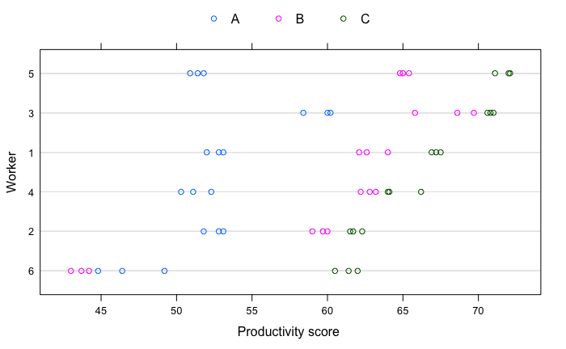

```r
plot(Machines)
```

# Different random term models

General model call is `lme(score ~ Machine, data = Machines, random = list(...))` with `...` replaced with below presented declarations of the random effects (or replacement of the whole term *random = …* with the simplified alternative)

## Worker = pdIdent(~1) or `random = ~ 1 | Worker`

Equal variances of the general mean (intercept) for all levels of random variable (Worker)

```r
fm1Machine <- lme(score ~ Machine, data = Machines, random = ~ 1 | Worker)
fm1Machine
```

```
Linear mixed-effects model fit by REML
  Data: Machines
  Log-restricted-likelihood: -143.4391
  Fixed: score ~ Machine
(Intercept)    MachineB    MachineC
  52.355556    7.966667   13.916667

Random effects:
 Formula: ~1 | Worker
        (Intercept) Residual
StdDev:    5.146552 3.161647

Number of Observations: 54
Number of Groups: 6
```

```r
VarCorr(fm1Machine)
```

```
Worker = pdLogChol(1)
            Variance  StdDev
(Intercept) 26.486998 5.146552
Residual     9.996014 3.161647
```

```r
fm1Machine$modelStruct$reStruct$Worker
```

```
Positive definite matrix structure of class pdLogChol representing
            (Intercept)
(Intercept)    2.649756
```

```r
corMatrix(fm1Machine$modelStruct$reStruct$Worker)
```

```
            (Intercept)
(Intercept)           1
attr(,"stdDev")
(Intercept)
   1.627807
```

```r
ranef(fm1Machine)
```

```
  (Intercept)
6 -8.70711058
2 -1.59425968
4 -0.06931564
1  1.21035769
3  6.21174760
5  2.94858062
```

## Worker = pdIdent(~1), Machine = pdIdent(~1) or `random = ~ 1 | Worker/Machine`

Equal variances of the general mean (intercept) for all levels of outer random variable (Worker) and combinations of both (Worker:Machine)

```r
fm2Machine <- update( fm1Machine, random = list(Worker = pdIdent(~1), Machine = pdIdent(~1)) )
#fm2Machine <- update( fm1Machine, random = ~ 1 | Worker/Machine )
fm2Machine
```

```
Linear mixed-effects model fit by REML
  Data: Machines
  Log-restricted-likelihood: -107.8438
  Fixed: score ~ Machine
(Intercept)    MachineB    MachineC
  52.355556    7.966667   13.916667

Random effects:
 Formula: ~1 | Worker
        (Intercept)
StdDev:     4.78105

 Formula: ~1 | Machine %in% Worker
        (Intercept)  Residual
StdDev:    3.729532 0.9615771

Number of Observations: 54
Number of Groups:
             Worker Machine %in% Worker
                  6                  18
```

```r
VarCorr(fm2Machine)
```

```
            Variance   StdDev
Worker =    pdIdent(1)
(Intercept) 22.8584377 4.7810499
Machine =   pdIdent(1)
(Intercept) 13.9094086 3.7295320
Residual     0.9246306 0.9615771
```

```r
fm2Machine$modelStruct$reStruct$Worker
```

```
Positive definite matrix structure of class pdIdent representing
            (Intercept)
(Intercept)     24.7217
```

```r
fm2Machine$modelStruct$reStruct$Machine
```

```
Positive definite matrix structure of class pdIdent representing
            (Intercept)
(Intercept)    15.04321
```

```r
corMatrix(fm2Machine$modelStruct$reStruct)
```

```
$Worker
            (Intercept)
(Intercept)           1
attr(,"stdDev")
(Intercept)
   4.972092

$Machine
            (Intercept)
(Intercept)           1
attr(,"stdDev")
(Intercept)
   3.878557
```

```r
ranef(fm2Machine)
```

```
Level: Worker
  (Intercept)
6 -7.51429458
2 -1.37585675
4 -0.05981986
1  1.04454677
3  5.36077966
5  2.54464477

Level: Machine %in% Worker
    (Intercept)
6/A   1.9162774
6/B  -8.9757070
6/C   2.4869652
2/A   1.5525655
2/B   0.6068543
2/C  -2.9966316
4/A  -1.0393716
4/B   2.4173660
4/C  -1.4143950
1/A  -0.7501469
1/B   1.4999936
1/C  -0.1142377
3/A   1.7776091
3/B   2.2993809
3/C  -0.8149440
5/A  -3.4569335
5/B   2.1521123
5/C   2.8532431
```

## Worker = pdSymm(~Machine-1)

Equivalent to `random = ~Machine-1|Worker` Different variances of the Machine effects for all levels of outer random variable (Worker) and combinations of both (Worker:Machine)

```r
  fm3Machine <- update(fm1Machine, random = pdSymm(~Machine-1))
  # same as fm3Machine2 <- update(fm1Machine, random = ~Machine-1|Worker)
  fm3Machine # == fm3Machine2
```

```
Linear mixed-effects model fit by REML
  Data: Machines
  Log-restricted-likelihood: -104.1556
  Fixed: score ~ Machine
(Intercept)    MachineB    MachineC
  52.355556    7.966667   13.916667

Random effects:
 Formula: ~Machine - 1 | Worker
 Structure: General positive-definite
         StdDev    Corr
MachineA 4.0792807 MachnA MachnB
MachineB 8.6252908 0.803
MachineC 4.3894795 0.623  0.771
Residual 0.9615766

Number of Observations: 54
Number of Groups: 6
```

```r
  VarCorr(fm3Machine)
```

```
Worker = pdSymm(Machine - 1)
         Variance   StdDev    Corr
MachineA 16.6405306 4.0792807 MachnA MachnB
MachineB 74.3956411 8.6252908 0.803
MachineC 19.2675306 4.3894795 0.623  0.771
Residual  0.9246296 0.9615766
```

```r
  fm3Machine$modelStruct$reStruct$Worker
```

```
Positive definite matrix structure of class pdSymm representing
         MachineA MachineB MachineC
MachineA 17.99697 30.54709 12.05512
MachineB 30.54709 80.45994 31.56299
MachineC 12.05512 31.56299 20.83811
```

```r
  corMatrix(fm3Machine$modelStruct$reStruct$Worker)
```

```
          MachineA  MachineB  MachineC
MachineA 1.0000000 0.8027499 0.6225047
MachineB 0.8027499 1.0000000 0.7708309
MachineC 0.6225047 0.7708309 1.0000000
attr(,"stdDev")
MachineA MachineB MachineC
4.242283 8.969946 4.564877
```

```r
  ranef(fm3Machine)
```

```
    MachineA    MachineB   MachineC
6 -5.5916013 -16.5838056 -5.0300737
2  0.1838844  -0.8033247 -4.2822823
4 -1.0238706   2.3284558 -1.4146283
1  0.3119890   2.5532237  0.9302963
3  6.9692218   7.7793500  4.4735105
5 -0.8496233   4.7261008  5.3231775
```

## Worker = pdCompSymm(~Machine-1)

```r
  fm4Machine <- update(fm3Machine, random = pdCompSymm(~Machine-1))
  fm4Machine
```

```
Linear mixed-effects model fit by REML
  Data: Machines
  Log-restricted-likelihood: -107.8438
  Fixed: score ~ Machine
(Intercept)    MachineB    MachineC
  52.355556    7.966667   13.916667

Random effects:
 Formula: ~Machine - 1 | Worker
 Structure: Compound Symmetry
         StdDev    Corr
MachineA 6.0636541
MachineB 6.0636541 0.622
MachineC 6.0636541 0.622 0.622
Residual 0.9615766

Number of Observations: 54
Number of Groups: 6
```

```r
  fm4Machine$modelStruct$reStruct$Worker
```

```
Positive definite matrix structure of class pdCompSymm representing
         MachineA MachineB MachineC
MachineA 39.76500 24.72173 24.72173
MachineB 24.72173 39.76500 24.72173
MachineC 24.72173 24.72173 39.76500
```

```r
  ranef(fm4Machine)
```

```
    MachineA    MachineB   MachineC
6 -5.5980169 -16.4900024 -5.0273291
2  0.1767089  -0.7690024 -4.3724886
4 -1.0991915   2.3575464 -1.4742150
1  0.2943997   2.5445405  0.9303091
3  7.1383889   7.6601607  4.5458355
5 -0.9122891   4.6967573  5.3978881
```

## Worker = pdIdent(~Machine-1))

```r
  fm4Machine_ID <- update(fm3Machine, random = pdIdent(~Machine-1))
  fm4Machine_ID
```

```
Linear mixed-effects model fit by REML
  Data: Machines
  Log-restricted-likelihood: -110.6278
  Fixed: score ~ Machine
(Intercept)    MachineB    MachineC
  52.355556    7.966667   13.916667

Random effects:
 Formula: ~Machine - 1 | Worker
 Structure: Multiple of an Identity
        MachineA MachineB MachineC  Residual
StdDev: 6.063654 6.063654 6.063654 0.9615766

Number of Observations: 54
Number of Groups: 6
```

```r
  fm4Machine_ID$modelStruct$reStruct$Worker
```

```
Positive definite matrix structure of class pdIdent representing
         MachineA MachineB MachineC
MachineA   39.765    0.000    0.000
MachineB    0.000   39.765    0.000
MachineC    0.000    0.000   39.765
```

```r
  ranef(fm4Machine_ID)
```

```
    MachineA    MachineB   MachineC
6 -5.5093728 -16.5501559 -4.9308887
2  0.2093562  -0.7492747 -4.4019889
4 -1.1128933   2.3910678 -1.4930400
1  0.2754686   2.5563490  0.9200653
3  7.1181097   7.6470094  4.4901388
5 -0.9806684   4.7050044  5.4157135
```

## Worker = pdIdent(~Worker-1)

```r
  fm4Machine_W <- update(fm3Machine, random = pdIdent(~Worker-1))
  fm4Machine_W
```

```
Linear mixed-effects model fit by REML
  Data: Machines
  Log-restricted-likelihood: -143.4391
  Fixed: score ~ Machine
(Intercept)    MachineB    MachineC
  52.355556    7.966667   13.916667

Random effects:
 Formula: ~Worker - 1 | Worker
 Structure: Multiple of an Identity
         Worker6  Worker2  Worker4  Worker1  Worker3  Worker5 Residual
StdDev: 5.146552 5.146552 5.146552 5.146552 5.146552 5.146552 3.161647

Number of Observations: 54
Number of Groups: 6
```

```r
  fm4Machine_W$modelStruct$reStruct$Worker
```

```
Positive definite matrix structure of class pdIdent representing
         Worker6  Worker2  Worker4  Worker1  Worker3  Worker5
Worker6 2.649755 0.000000 0.000000 0.000000 0.000000 0.000000
Worker2 0.000000 2.649755 0.000000 0.000000 0.000000 0.000000
Worker4 0.000000 0.000000 2.649755 0.000000 0.000000 0.000000
Worker1 0.000000 0.000000 0.000000 2.649755 0.000000 0.000000
Worker3 0.000000 0.000000 0.000000 0.000000 2.649755 0.000000
Worker5 0.000000 0.000000 0.000000 0.000000 0.000000 2.649755
```

```r
  VarCorr(fm4Machine_W)
```

```
Worker = pdIdent(Worker - 1)
         Variance  StdDev
Worker6  26.486993 5.146552
Worker2  26.486993 5.146552
Worker4  26.486993 5.146552
Worker1  26.486993 5.146552
Worker3  26.486993 5.146552
Worker5  26.486993 5.146552
Residual  9.996015 3.161647
```

```r
  ranef(fm4Machine_W)
```

```
    Worker6  Worker2     Worker4  Worker1  Worker3  Worker5
6 -8.707111  0.00000  0.00000000 0.000000 0.000000 0.000000
2  0.000000 -1.59426  0.00000000 0.000000 0.000000 0.000000
4  0.000000  0.00000 -0.06931564 0.000000 0.000000 0.000000
1  0.000000  0.00000  0.00000000 1.210358 0.000000 0.000000
3  0.000000  0.00000  0.00000000 0.000000 6.211748 0.000000
5  0.000000  0.00000  0.00000000 0.000000 0.000000 2.948581
```

```r
  coef(fm4Machine_W)
```

```
  (Intercept) MachineB MachineC   Worker6  Worker2     Worker4  Worker1  Worker3  Worker5
6    52.35556 7.966667 13.91667 -8.707111  0.00000  0.00000000 0.000000 0.000000 0.000000
2    52.35556 7.966667 13.91667  0.000000 -1.59426  0.00000000 0.000000 0.000000 0.000000
4    52.35556 7.966667 13.91667  0.000000  0.00000 -0.06931564 0.000000 0.000000 0.000000
1    52.35556 7.966667 13.91667  0.000000  0.00000  0.00000000 1.210358 0.000000 0.000000
3    52.35556 7.966667 13.91667  0.000000  0.00000  0.00000000 0.000000 6.211748 0.000000
5    52.35556 7.966667 13.91667  0.000000  0.00000  0.00000000 0.000000 0.000000 2.948581
```

## Worker = pdCompSymm(~Worker-1)

```r
  fm4Machine_WCS <- update(fm3Machine, random = pdCompSymm(~Worker-1))
  fm4Machine_WCS
```

```
Linear mixed-effects model fit by REML
  Data: Machines
  Log-restricted-likelihood: -143.4391
  Fixed: score ~ Machine
(Intercept)    MachineB    MachineC
  52.355556    7.966667   13.916667

Random effects:
 Formula: ~Worker - 1 | Worker
 Structure: Compound Symmetry
         StdDev   Corr
Worker6  5.146552
Worker2  5.146552 0
Worker4  5.146552 0    0
Worker1  5.146552 0    0 0
Worker3  5.146552 0    0 0 0
Worker5  5.146552 0    0 0 0 0
Residual 3.161647

Number of Observations: 54
Number of Groups: 6
```

```r
  fm4Machine_WCS$modelStruct$reStruct$Worker
```

```
Positive definite matrix structure of class pdCompSymm representing
             Worker6      Worker2      Worker4      Worker1      Worker3      Worker5
Worker6 2.649755e+00 1.149404e-07 1.149404e-07 1.149404e-07 1.149404e-07 1.149404e-07
Worker2 1.149404e-07 2.649755e+00 1.149404e-07 1.149404e-07 1.149404e-07 1.149404e-07
Worker4 1.149404e-07 1.149404e-07 2.649755e+00 1.149404e-07 1.149404e-07 1.149404e-07
Worker1 1.149404e-07 1.149404e-07 1.149404e-07 2.649755e+00 1.149404e-07 1.149404e-07
Worker3 1.149404e-07 1.149404e-07 1.149404e-07 1.149404e-07 2.649755e+00 1.149404e-07
Worker5 1.149404e-07 1.149404e-07 1.149404e-07 1.149404e-07 1.149404e-07 2.649755e+00
```

```r
  VarCorr(fm4Machine_WCS)
```

```
Worker = pdCompSymm(Worker - 1)
         Variance  StdDev   Corr
Worker6  26.486993 5.146552
Worker2  26.486993 5.146552 0
Worker4  26.486993 5.146552 0    0
Worker1  26.486993 5.146552 0    0 0
Worker3  26.486993 5.146552 0    0 0 0
Worker5  26.486993 5.146552 0    0 0 0 0
Residual  9.996015 3.161647
```

```r
  ranef(fm4Machine_WCS)
```

```
        Worker6       Worker2       Worker4       Worker1       Worker3       Worker5
6 -8.707111e+00 -3.776949e-07 -3.776949e-07 -3.776949e-07 -3.776949e-07 -3.776949e-07
2 -6.915541e-08 -1.594260e+00 -6.915542e-08 -6.915540e-08 -6.915541e-08 -6.915541e-08
4 -3.006757e-09 -3.006729e-09 -6.931564e-02 -3.006753e-09 -3.006753e-09 -3.006757e-09
1  5.250260e-08  5.250264e-08  5.250259e-08  1.210358e+00  5.250260e-08  5.250259e-08
3  2.694517e-07  2.694517e-07  2.694517e-07  2.694517e-07  6.211748e+00  2.694517e-07
5  1.279028e-07  1.279028e-07  1.279028e-07  1.279028e-07  1.279028e-07  2.948581e+00
```

```r
  coef(fm4Machine_WCS)
```

```
  (Intercept) MachineB MachineC       Worker6       Worker2       Worker4       Worker1       Worker3       Worker5
6    52.35556 7.966667 13.91667 -8.707111e+00 -3.776949e-07 -3.776949e-07 -3.776949e-07 -3.776949e-07 -3.776949e-07
2    52.35556 7.966667 13.91667 -6.915541e-08 -1.594260e+00 -6.915542e-08 -6.915540e-08 -6.915541e-08 -6.915541e-08
4    52.35556 7.966667 13.91667 -3.006757e-09 -3.006729e-09 -6.931564e-02 -3.006753e-09 -3.006753e-09 -3.006757e-09
1    52.35556 7.966667 13.91667  5.250260e-08  5.250264e-08  5.250259e-08  1.210358e+00  5.250260e-08  5.250259e-08
3    52.35556 7.966667 13.91667  2.694517e-07  2.694517e-07  2.694517e-07  2.694517e-07  6.211748e+00  2.694517e-07
5    52.35556 7.966667 13.91667  1.279028e-07  1.279028e-07  1.279028e-07  1.279028e-07  1.279028e-07  2.948581e+00
```

## Worker = pdDiag(~Worker-1)

```r
  fm4Machine_WDiag <- update(fm3Machine, random = pdDiag(~Worker-1))
  fm4Machine_WDiag
```

```
Linear mixed-effects model fit by REML
  Data: Machines
  Log-restricted-likelihood: -140.4044
  Fixed: score ~ Machine
(Intercept)    MachineB    MachineC
  52.972597    7.966667   13.916667

Random effects:
 Formula: ~Worker - 1 | Worker
 Structure: Diagonal
         Worker6  Worker2      Worker4      Worker1  Worker3  Worker5 Residual
StdDev: 9.655951 2.132026 0.0004869744 0.0002866349 5.799888 2.320231 3.149278

Number of Observations: 54
Number of Groups: 6
```

```r
  fm4Machine_WDiag$modelStruct$reStruct$Worker
```

```
Positive definite matrix structure of class pdDiag representing
         Worker6   Worker2      Worker4      Worker1  Worker3   Worker5
Worker6 9.400868 0.0000000 0.000000e+00 0.000000e+00 0.000000 0.0000000
Worker2 0.000000 0.4583139 0.000000e+00 0.000000e+00 0.000000 0.0000000
Worker4 0.000000 0.0000000 2.391059e-08 0.000000e+00 0.000000 0.0000000
Worker1 0.000000 0.0000000 0.000000e+00 8.283922e-09 0.000000 0.0000000
Worker3 0.000000 0.0000000 0.000000e+00 0.000000e+00 3.391698 0.0000000
Worker5 0.000000 0.0000000 0.000000e+00 0.000000e+00 0.000000 0.5428007
```

```r
  VarCorr(fm4Machine_WDiag)
```

```
Worker = pdDiag(Worker - 1)
         Variance     StdDev
Worker6  9.323739e+01 9.6559507947
Worker2  4.545537e+00 2.1320264598
Worker4  2.371441e-07 0.0004869744
Worker1  8.215956e-08 0.0002866349
Worker3  3.363870e+01 5.7998883367
Worker5  5.383473e+00 2.3202312402
Residual 9.917955e+00 3.1492784496
```

```r
  ranef(fm4Machine_WDiag)
```

```
    Worker6  Worker2       Worker4      Worker1  Worker3  Worker5
6 -9.576081  0.00000  0.000000e+00 0.000000e+00 0.000000 0.000000
2  0.000000 -1.83362  0.000000e+00 0.000000e+00 0.000000 0.000000
4  0.000000  0.00000 -1.483262e-07 0.000000e+00 0.000000 0.000000
1  0.000000  0.00000  0.000000e+00 4.801882e-08 0.000000 0.000000
3  0.000000  0.00000  0.000000e+00 0.000000e+00 5.669451 0.000000
5  0.000000  0.00000  0.000000e+00 0.000000e+00 0.000000 2.038003
```

```r
  coef(fm4Machine_WDiag)
```

```
  (Intercept) MachineB MachineC   Worker6  Worker2       Worker4      Worker1  Worker3  Worker5
6     52.9726 7.966667 13.91667 -9.576081  0.00000  0.000000e+00 0.000000e+00 0.000000 0.000000
2     52.9726 7.966667 13.91667  0.000000 -1.83362  0.000000e+00 0.000000e+00 0.000000 0.000000
4     52.9726 7.966667 13.91667  0.000000  0.00000 -1.483262e-07 0.000000e+00 0.000000 0.000000
1     52.9726 7.966667 13.91667  0.000000  0.00000  0.000000e+00 4.801882e-08 0.000000 0.000000
3     52.9726 7.966667 13.91667  0.000000  0.00000  0.000000e+00 0.000000e+00 5.669451 0.000000
5     52.9726 7.966667 13.91667  0.000000  0.00000  0.000000e+00 0.000000e+00 0.000000 2.038003
```

## Comparison of models for Workers

```r
  plot(resid(fm4Machine_WDiag)~fitted(fm4Machine_WDiag))
  points(resid(fm4Machine_W)~fitted(fm4Machine_W), col="red")
```

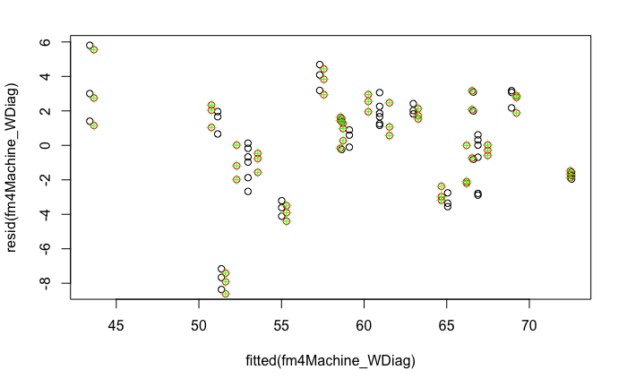

```r
  points(resid(fm4Machine_WCS)~fitted(fm4Machine_WCS), col="green", pch=3)
```

```r
  anova(fm4Machine_W, fm4Machine_WCS, fm4Machine_WDiag)
```

|  | Model | df | AIC | BIC | logLik | Test | L.Ratio | p-value |
| --- | --- | --- | --- | --- | --- | --- | --- | --- |
| fm4Machine_W | 1 | 5 | 296.8782 | 306.5373 | -143.4391 |  |  |  |
| fm4Machine_WCS | 2 | 6 | 298.8782 | 310.4692 | -143.4391 | 1 vs 2 | 0.000000 | 1.000 |
| fm4Machine_WDiag | 3 | 10 | 300.8089 | 320.1271 | -140.4044 | 2 vs 3 | 6.069345 | 0.194 |

```r
  fm4Machine_Blocked <- lme(score ~ Machine, data = Machines, random = list(Worker = pdBlocked(list( pdDiag(~Machine-1), pdDiag(~Worker-1)))))
  fm4Machine_Blocked
```

```
Linear mixed-effects model fit by REML
  Data: Machines
  Log-restricted-likelihood: -101.1671
  Fixed: score ~ Machine
(Intercept)    MachineB    MachineC
  52.048993    7.966667   13.916667

Random effects:
 Composite Structure: Blocked

 Block 1: MachineA, MachineB, MachineC
 Formula: ~Machine - 1 | Worker
 Structure: Diagonal
         MachineA MachineB MachineC
StdDev: 0.3841157 5.755022 3.421381

 Block 2: Worker6, Worker2, Worker4, Worker1, Worker3, Worker5
 Formula: ~Worker - 1 | Worker
 Structure: Diagonal
         Worker6      Worker2  Worker4   Worker1  Worker3      Worker5  Residual
StdDev: 5.343679 0.0001218991 0.554491 0.3159856 7.374898 0.0001095451 0.9615766

Number of Observations: 54
Number of Groups: 6
```

```r
  fm4Machine_Blocked$modelStruct$reStruct$Worker
```

```
Positive definite matrix structure of class pdBlocked representing
          MachineA MachineB MachineC  Worker6      Worker2   Worker4   Worker1 Worker3      Worker5
MachineA 0.1595719  0.00000  0.00000  0.00000 0.000000e+00 0.0000000 0.0000000  0.0000 0.000000e+00
MachineB 0.0000000 35.82005  0.00000  0.00000 0.000000e+00 0.0000000 0.0000000  0.0000 0.000000e+00
MachineC 0.0000000  0.00000 12.66004  0.00000 0.000000e+00 0.0000000 0.0000000  0.0000 0.000000e+00
Worker6  0.0000000  0.00000  0.00000 30.88253 0.000000e+00 0.0000000 0.0000000  0.0000 0.000000e+00
Worker2  0.0000000  0.00000  0.00000  0.00000 1.607063e-08 0.0000000 0.0000000  0.0000 0.000000e+00
Worker4  0.0000000  0.00000  0.00000  0.00000 0.000000e+00 0.3325226 0.0000000  0.0000 0.000000e+00
Worker1  0.0000000  0.00000  0.00000  0.00000 0.000000e+00 0.0000000 0.1079858  0.0000 0.000000e+00
Worker3  0.0000000  0.00000  0.00000  0.00000 0.000000e+00 0.0000000 0.0000000 58.8226 0.000000e+00
Worker5  0.0000000  0.00000  0.00000  0.00000 0.000000e+00 0.0000000 0.0000000  0.0000 1.297832e-08
```

```r
  VarCorr(fm4Machine_Blocked)
```

```
Worker = pdDiag(Machine - 1), pdDiag(Worker - 1)
         Variance     StdDev
MachineA 1.475449e-01 0.3841157358
MachineB 3.312028e+01 5.7550221168
MachineC 1.170585e+01 3.4213813826
Worker6  2.855491e+01 5.3436789966
Worker2  1.485938e-08 0.0001218991
Worker4  3.074602e-01 0.5544909588
Worker1  9.984689e-02 0.3159855865
Worker3  5.438911e+01 7.3748975717
Worker5  1.200013e-08 0.0001095451
Residual 9.246296e-01 0.9615766122
```

```r
  ranef(fm4Machine_Blocked)
```

```
     MachineA    MachineB   MachineC   Worker6     Worker2    Worker4   Worker1 Worker3       Worker5
6  0.01391431 -10.9881003  0.6102460 -5.291973 0.00000e+00  0.0000000 0.0000000 0.00000  0.000000e+00
2  0.16759040  -0.4448532 -4.0263151  0.000000 1.15676e-08  0.0000000 0.0000000 0.00000  0.000000e+00
4 -0.15877114   3.0148461 -0.8513494  0.000000 0.00000e+00 -0.3252278 0.0000000 0.00000  0.000000e+00
1  0.15052288   2.7394607  1.0863504  0.000000 0.00000e+00  0.0000000 0.1193869 0.00000  0.000000e+00
3  0.04763813   0.6742098 -2.4386412  0.000000 0.00000e+00  0.0000000 0.0000000 7.33719  0.000000e+00
5 -0.22089457   5.0044369  5.6197093  0.000000 0.00000e+00  0.0000000 0.0000000 0.00000 -1.039162e-08
```

```r
  coef(fm4Machine_Blocked)
```

```
  (Intercept)  MachineB  MachineC    MachineA   Worker6     Worker2    Worker4   Worker1 Worker3       Worker5
6    52.04899 -3.021434 14.526913  0.01391431 -5.291973 0.00000e+00  0.0000000 0.0000000 0.00000  0.000000e+00
2    52.04899  7.521813  9.890352  0.16759040  0.000000 1.15676e-08  0.0000000 0.0000000 0.00000  0.000000e+00
4    52.04899 10.981513 13.065317 -0.15877114  0.000000 0.00000e+00 -0.3252278 0.0000000 0.00000  0.000000e+00
1    52.04899 10.706127 15.003017  0.15052288  0.000000 0.00000e+00  0.0000000 0.1193869 0.00000  0.000000e+00
3    52.04899  8.640876 11.478026  0.04763813  0.000000 0.00000e+00  0.0000000 0.0000000 7.33719  0.000000e+00
5    52.04899 12.971104 19.536376 -0.22089457  0.000000 0.00000e+00  0.0000000 0.0000000 0.00000 -1.039162e-08
```

```r
  fm4Machine_Blocked$coefficients$fixed
```

```
(Intercept)    MachineB    MachineC
  52.048993    7.966667   13.916667
```

```r
  fm4Machine_Blocked$coefficients$random
```

```
$Worker
     MachineA    MachineB   MachineC   Worker6     Worker2    Worker4   Worker1 Worker3       Worker5
6  0.01391431 -10.9881003  0.6102460 -5.291973 0.00000e+00  0.0000000 0.0000000 0.00000  0.000000e+00
2  0.16759040  -0.4448532 -4.0263151  0.000000 1.15676e-08  0.0000000 0.0000000 0.00000  0.000000e+00
4 -0.15877114   3.0148461 -0.8513494  0.000000 0.00000e+00 -0.3252278 0.0000000 0.00000  0.000000e+00
1  0.15052288   2.7394607  1.0863504  0.000000 0.00000e+00  0.0000000 0.1193869 0.00000  0.000000e+00
3  0.04763813   0.6742098 -2.4386412  0.000000 0.00000e+00  0.0000000 0.0000000 7.33719  0.000000e+00
5 -0.22089457   5.0044369  5.6197093  0.000000 0.00000e+00  0.0000000 0.0000000 0.00000 -1.039162e-08
```